# Methods for testing publication bias in ecological and evolutionary meta-analyses

Supplementary Information Appendix S2 - Publication bias tests for ecology & evolution

Shinichi Nakagawa, Malgorzata Lagisz, Michael D. Jennions, Julia Koricheva, Daniel W.A. Noble, Timothy H. Parker, Alfredo Sanchez-Tojar, Yefeng Yang, Rose O’Dea

10 February, 2021

## 1 - Correlation effect sizes

```r
# importing dataset with correlation coefficients
# dataset.r.original <- read.csv("../data/Sanchez-Tojar_et_al_2018_eLife_Meta4.csv", stringsAsFactors = FALSE)
dataset.r.original <- read.csv("ft177.csv", stringsAsFactors = FALSE)

# for the example, only analyzing the subset of the data based on observational studies, since
# observational and experimental studies were analyzed separately, and observational is by far
# the largest dataset
# From the article: "We analysed observational (n = 516) and experimental (n = 37) data separately"
dataset.r.original <- dataset.r.original[dataset.r.original$experimental.design=="observational",]

# double-checking that the number of effects corresponds to what is written in the article: yes, it does
nrow(dataset.r.original) #516
```

### 1.1 - Meta-analytic model

```r
# From the article:
# We controlled for host phylogenetic non‐independence following Becker et al. (2018),
# and used the rotl and ape packages to extract the phylogeny, prune the tree,
# resolve multichotomies and provide branch lengths (Grafen 1989; Paradis et al. 2004;
# Michonneau et al. 2016). We nested observations within a study to account for
# unit‐level variance and study pseudoreplication, as half of all studies contained
# more than one effect size (103/199).

# creating a unit-level random effect to model residual variance in metafor
dataset.r.original$obsID <- 1:nrow(dataset.r.original)

# running multilevel intercept-only meta-analytic model
meta.analysis.model.1 <- rma.mv(yi, vi,
                                mods=~1,
                                random=list(~ 1 | obsID, ~ 1 | study),
                                method="REML",data=dataset.r.original)

# extracting the mean, 95% confidence intervals and 95% prediction intervals
#print(meta.analysis.model.1, digits=3)
metaanalytic.mean.model.1 <- predict(meta.analysis.model.1, digits=3)
#forest(meta.analysis.model.1)

# estimating relative heterogeneity I2
I2.model.1 <- I2(meta.analysis.model.1,method = c("Shinichi"))*100

# and absolute heterogeneity Q
Q.model.1 <- c(meta.analysis.model.1$QE)

# creating a table to show the heterogeneity estimates
table.model.1 <- data.frame(n=length(unique(dataset.r.original$study)),
                            k=nrow(dataset.r.original),
                            mean=round(metaanalytic.mean.model.1[[1]],2),
                            CI=paste0("[",round(metaanalytic.mean.model.1[[3]],2),",",round(metaanalytic.mean.model.1[[4]],2),"]"),
                            PI=paste0("[",round(metaanalytic.mean.model.1[[5]],2),",",round(metaanalytic.mean.model.1[[6]],2),"]"),
                            I2_obsID=round(I2.model.1[2],1),
                            I2_paperID=round(I2.model.1[3],1),
                            #I2_popID2=round(I2.model.1[4],1),
                            I2_total=round(I2.model.1[1],1),
                            Q=round(Q.model.1,1))

rownames(table.model.1) <- NULL

# creating a fancy table using the R package 'gt'
table.model.1.gt <- table.model.1 %>%
  gt() %>%
  cols_label(n=md("**n**"),
             k=md("**k**"),
             mean=md("**Meta-analytic mean**"),
             CI=md("**95% CI**"),
             PI=md("**95% PI**"),
             I2_obsID=md("***I*<sup>2</sup><sub>residual</sub> (%)**"),
             I2_paperID=md("***I*<sup>2</sup><sub>study</sub> (%)**"),
             #I2_popID2=md("***I*<sup>2</sup><sub>population</sub> (%)**"),
             #Phylogeny=md("***I*<sup>2</sup><sub>Phylo</sub> (%)**"),
             I2_total=md("***I*<sup>2</sup><sub>total</sub> (%)**"),
             Q=md("***Q*<sub>test</sub>**")) %>%
  cols_align(align = "center") %>%
  tab_source_note(source_note = md("n = number of studies; k = number of effects; CI = confidence interval; PI = prediction interval; *I*<sup>2</sup> = heterogeneity; *Q*<sub>test</sub> = Cochrane's *Q* test.")) %>%
  tab_options(table.width=775)

table.model.1.gt
```

| **n** | **k** | **Meta-analytic mean** | **95% CI** | **95% PI** | *I*<sup>2</sup><sub>residual</sub> (%) | *I*<sup>2</sup><sub>study</sub> (%) | *I*<sup>2</sup><sub>total</sub> (%) | *Q*<sub>test</sub> |
| --- | --- | --- | --- | --- | --- | --- | --- | --- |
| 168 | 516 | -0.13 | [-0.18,-0.08] | [-0.83,0.56] | 35.7 | 59.8 | 95.5 | 6769 |

**Table S1.** Results of the multilevel intercept-only meta-analysis testing the relationship between body condition and parasite infection across species. Estimates are presented as standardized effect sizes using Fisher’s transformation (i.e. *Zr*).

### 1.2 - Publication bias

#### **1.2.1 - The two-step approach**

To test for small-study effects, we are going to follow the two-step approach that we suggested in the main text. First, we run a multilevel meta-regression that has the same random effect structure as the meta-analytic model (Table S1) and that includes the effect sizes’ standard errors (SE or sei) as the only moderator (see Equation 21 from the main text). If the slope of this moderator is statistically significant, then we run an additional multilevel meta-regression including the effect sizes’ sampling variances (SV or vi) as the only moderator (see Equation 22 from the main text), which allows us to obtain an overall effect (the intercept or B0) after accounting for small-study bias, and this overall is less downwardly biased when modeling sampling variance than when modeling standard errors (more in the main text; Doucouliagos 2012, 2014).

```r
# creating a varible for the standard error of each effect size (i.e. the square root of the sampling variance, see Figure 1 from the main manuscript)
dataset.r.original$sei <- sqrt(dataset.r.original$vi)

# Application of Equation 21 from the main manuscript
publication.bias.model.1.se <- rma.mv(yi, vi,
                                      mods=~1+sei,
                                      random=list(~ 1 | obsID, ~ 1 | study),
                                      method="REML",data=dataset.r.original)

#print(publication.bias.model.1.se,digits=3)

# extracting the mean and 95% confidence intervals
estimates.publication.bias.model.1.se <- estimates.CI(publication.bias.model.1.se)
```

##### **1.2.1.1 - Modelling SE (Eq.21)**

According to the meta-regression, there is no evidence of small-study effects since the slope of the moderator (i.e. SE) is far from being statistically significant (**slope = -0.098, 95% CI = [-0.571,0.376]**; *R<sup>2</sup><sub>marginal</sub>* = 0.1%; Figure S1). Since there is no evidence of small-study bias, we do not need to model sampling variance for this two-step approach.

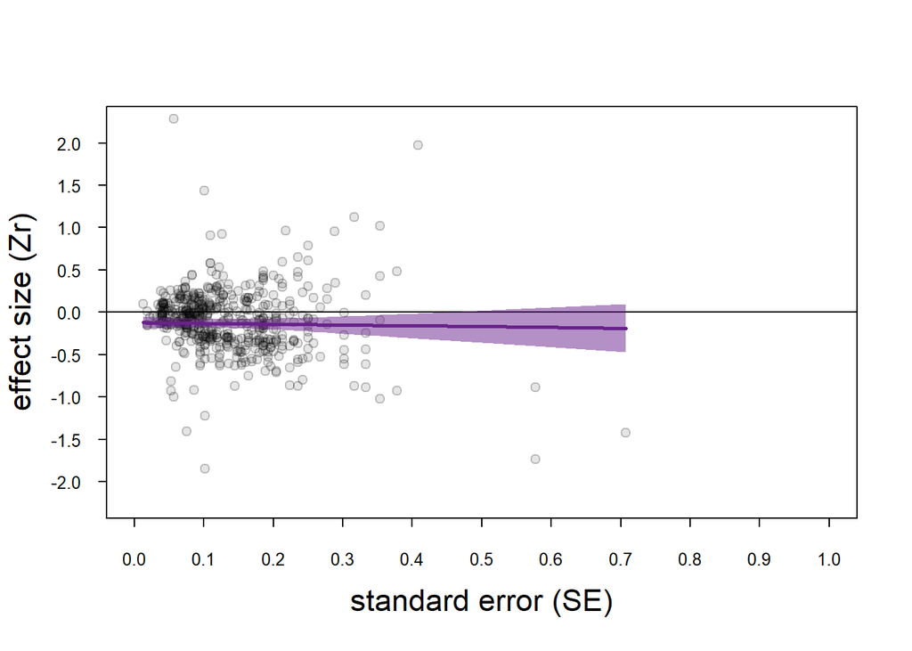

```r
publication.bias.model.1.se.plot <- predict(publication.bias.model.1.se)

newdat <- data.frame(sei=dataset.r.original$sei,
                     fit=publication.bias.model.1.se.plot$pred,
                     upper=publication.bias.model.1.se.plot$ci.ub,
                     lower=publication.bias.model.1.se.plot$ci.lb,
                     stringsAsFactors=FALSE)

#newdat <- unique(newdat[order(newdat$sei),])
newdat <- unique(newdat[order(newdat$sei),])

xaxis <- dataset.r.original$sei
yaxis <- dataset.r.original$yi

plot(xaxis,yaxis,
     type="n",
     ylab="",
     xlab="",
     xaxt="n",
     yaxt="n",
     ylim=c(-2.25,2.25),
     xlim=c(0,1))


abline(a=0,b=0, lwd=1, lty=1)


axis(1,at=seq(0,1,0.1),
     cex.axis=0.8,tck=-0.02)

axis(2,
     at=round(seq(-2.5,2.25,0.5),1),
     cex.axis=0.8,las=2,tck=-0.02)

title(xlab = "standard error (SE)",
      ylab = "effect size (Zr)",
      line = 2.75, cex.lab=1.4)

points(jitter(xaxis,2),yaxis,
       bg=rgb(0,0,0, 0.1),
       col=rgb(0,0,0, 0.2),
       pch=21,
       cex=1)

lines(newdat$sei, newdat$fit, lwd=2.75,col="darkorchid4")

polygon(c(newdat$sei,rev(newdat$sei)),
        c(newdat$lower,rev(newdat$upper)),
        border=NA,col=rgb(104/255,34/255,139/255, 0.5))
```

**Figure S1.** Effect sizes do not seem to change with SE, which suggest that there is no evidence of small-study effects in this meta-analytic dataset. The solid line represents the model estimate and shading shows the 95% confidence intervals.

##### **1.2.1.2 - Modelling SV (Eq.22)**

Not necessary, since the first step did not find evidence of small-study effects.

#### **1.2.2 - Time-lag bias test (Eq.23)**

To test for time-lag bias, also called decline effects, we are again going to fit a multilevel meta-regression that has the same random effect structure as the meta-analytic model (Table S1) and that includes the year of publication as the only moderator (see Equation 23 from the main text). The estimated slope for year will tell us whether effect sizes have become smaller over time since the first effect size was published.

```r
# creating a variable with the year of publication
dataset.r.original$year <- as.numeric(str_extract(dataset.r.original$study, "(\\d)+"))

# Application of Equation 23 from the main manuscript
publication.bias.model.1.timelag <- rma.mv(yi, vi,
                                           mods=~1+year,
                                           random=list(~ 1 | obsID, ~ 1 | study),
                                           method="REML",data=dataset.r.original)

#summary(publication.bias.model.1.timelag)

# extracting the mean and 95% confidence intervals
estimates.publication.bias.model.1.timelag <- estimates.CI(publication.bias.model.1.timelag)
```

The time-lag bias test shows little evidence for decline effects, although theres is a trend for the slope of year to be positive, meaning that effect sizes have trended towards zero over time (**year slope = 0.003; 95% CI = [-0.004,0.011]**; *R<sup>2</sup><sub>marginal</sub>* = 0.4%; Figure S2).

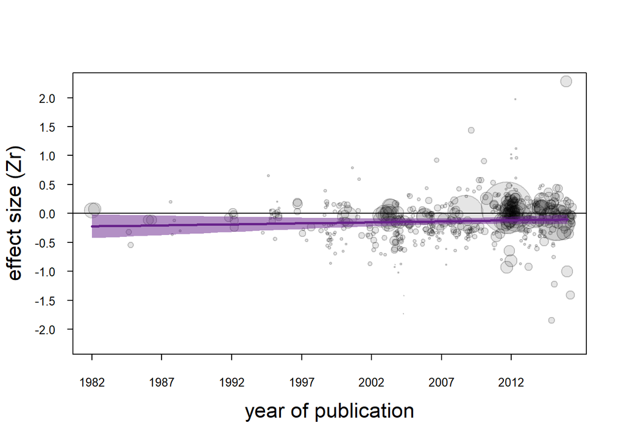

```r
publication.bias.model.1.timelag.plot <- predict(publication.bias.model.1.timelag,newmods=seq(min(dataset.r.original$year),max(dataset.r.original$year),1))

newdat <- data.frame(year=seq(min(dataset.r.original$year),max(dataset.r.original$year),1),
                     fit=publication.bias.model.1.timelag.plot$pred,
                     upper=publication.bias.model.1.timelag.plot$ci.ub,
                     lower=publication.bias.model.1.timelag.plot$ci.lb,
                     stringsAsFactors=FALSE)


xaxis <- dataset.r.original$year
yaxis <- dataset.r.original$yi
cex.study <- (1/dataset.r.original$sei)/10

plot(xaxis,yaxis,
     type="n",
     ylab="",
     xlab="",
     xaxt="n",
     yaxt="n",
     ylim=c(-2.25,2.25),
     xlim=c(min(xaxis),max(xaxis)))


abline(a=0,b=0, lwd=1, lty=1)


axis(1,at=seq(min(xaxis),max(xaxis),5),
     cex.axis=0.8,tck=-0.02)

axis(2,
     at=round(seq(-2.5,2.25,0.5),1),
     cex.axis=0.8,las=2,tck=-0.02)

title(xlab = "year of publication",
      ylab = "effect size (Zr)",
      line = 2.75, cex.lab=1.4)

points(jitter(xaxis,2),yaxis,
       bg=rgb(0,0,0, 0.1),
       col=rgb(0,0,0, 0.2),
       pch=21,
       cex=cex.study)

lines(newdat$year, newdat$fit, lwd=2.75,col="darkorchid4")

polygon(c(newdat$year,rev(newdat$year)),
        c(newdat$lower,rev(newdat$upper)),
        border=NA,col=rgb(104/255,34/255,139/255, 0.5))
```

#### 1.2.3 - **All-in publication bias test (Eq.24)**

Not necessary, since the first step did not find evidence of small-study effects.

## 2 - Mean differences between two groups

### 2.2 - Publication bias

#### 2.2.1.1 - **Sample size quared (Eq.27)**

#### 2.2.1.2 - **Sample size (Eq.28)**

#### 2.2.2 - **Time-lag bias test**

#### 2.2.3 - **All-in publication bias test (Eq.29)**

**R version 3.5.1 (2018-07-02)**

**Platform:** x86_64-w64-mingw32/x64 (64-bit)

**locale:** *LC_COLLATE=English_United States.1252*, *LC_CTYPE=English_United States.1252*, *LC_MONETARY=English_United States.1252*, *LC_NUMERIC=C* and *LC_TIME=English_United States.1252*

**attached base packages:** *stats*, *graphics*, *grDevices*, *utils*, *datasets*, *methods* and *base*

**other attached packages:** *stringr(v.1.4.0)*, *pander(v.0.6.3)*, *gt(v.0.1.0)*, *metafor(v.2.4-0)*, *Matrix(v.1.2-14)* and *dplyr(v.0.8.5)*

**loaded via a namespace (and not attached):** *Rcpp(v.1.0.4.6)*, *plyr(v.1.8.4)*, *pillar(v.1.3.1)*, *compiler(v.3.5.1)*, *base64enc(v.0.1-3)*, *tools(v.3.5.1)*, *digest(v.0.6.18)*, *evaluate(v.0.12)*, *tibble(v.2.1.1)*, *nlme(v.3.1-137)*, *checkmate(v.1.9.3)*, *gtable(v.0.2.0)*, *lattice(v.0.20-35)*, *pkgconfig(v.2.0.2)*, *rlang(v.0.4.8)*, *commonmark(v.1.7)*, *yaml(v.2.2.0)*, *xfun(v.0.5)*, *knitr(v.1.21)*, *vctrs(v.0.2.4)*, *sass(v.0.1.1)*, *grid(v.3.5.1)*, *tidyselect(v.1.1.0)*, *glue(v.1.3.1)*, *R6(v.2.4.0)*, *rmarkdown(v.1.11)*, *pacman(v.0.5.0)*, *purrr(v.0.3.4)*, *ggplot2(v.3.1.0)*, *magrittr(v.1.5)*, *backports(v.1.1.2)*, *scales(v.1.0.0)*, *htmltools(v.0.3.6)*, *assertthat(v.0.2.1)*, *colorspace(v.1.3-2)*, *stringi(v.1.4.3)*, *lazyeval(v.0.2.1)*, *munsell(v.0.5.0)* and *crayon(v.1.3.4)*